# ERCC RNA Spike-In

Gabriele Lubatti

17/06/2021

In this notebook it is shown the heteroplasmy analysis performed on mouse CI-treated epiblast cells from https://www.nature.com/articles/s42255-021-00422-7. As a technical control,we focus on heteroplasmy on ERCC-Spike-In.

## Get counts for the four alleles in each base-cell pair

```r
#if (!requireNamespace("devtools", quietly = TRUE)) install.packages("devtools")
#devtools::install_github("ScialdoneLab/RNAheteroplasmy",auth_token="be68e5a7d8bdb8c1d270488c463c6bcaa5#13acf7")
#library(RNAheteroplasmy)
```

```r
#if (!requireNamespace("devtools", quietly = TRUE)) install.packages("devtools")
#devtools::install_github("https://github.com/ScialdoneLab/MitoHEAR/tree/master",auth_token="#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")
library(MitoHEAR)
```

The first step of the library MitoHEAR is to generate a raw counts allele matrix with cells as rows and the four alleles for each base in the fasta file on the columns. This task is achieved with the function *get_raw_counts_allele*. As input we need to provide the sorted bam files (one for each cell, with full path), the fasta file of the genomic region of interest and the cell names. The matrix *after_qc* contains meta data information about the cells (i.e. cell names, cell types, batch).

```r
data("after_qc",package="MitoHEAR")

path_to_bam="/home/ies/gabriele.lubatti/revision_heteroplasmy/Cell_Competition_data/all_unique_bam_files_spikes/"

row.names(after_qc)=after_qc$new_name
cells_fmk_epi=after_qc[(after_qc$condition=="Cell competition OFF")&(after_qc$cluster==1|after_qc$cluster==3|after_qc$cluster==4),"new_name"]

after_qc_fmk_epi=after_qc[cells_fmk_epi,]

cell_names=as.vector(after_qc_fmk_epi$new_name)

bam_input=paste(path_to_bam,cell_names,".unique.bam",sep="")

path_fasta="/home/ies/gabriele.lubatti/revision_heteroplasmy/Cell_Competition_data/fasta_files/ERCC92.fa"

#setwd("/Users/gabriele.lubatti/Desktop/Phd/Heteroplasmy_library_R/Input_data_R_server")
#vedo=load("output_SNP_mt.Rda")
#save(cell_names,file="cell_names.Rda")
#save(bam_input,file="bam_input.Rda")
```

We don’t execute the function *get_raw_counts_allele* here and we directly load its output. A command line implementation of the function *get_raw_counts_allele* is also available (see github README file for info).

```r
#output_SNP_spikes=get_raw_counts_allele(bam_input,path_fasta,cell_names)

# Command line implementation
#cd /home/ies/gabriele.lubatti/revision_heteroplasmy/Cell_Competition_data/R_files
#Rscript --vanilla /home/ies/gabriele.lubatti/revision_heteroplasmy/Cell_Competition_data/R_files/get_r#aw_counts_allele_script.R -b bam_input_spikes  -f #"/home/ies/gabriele.lubatti/revision_heteroplasmy/Cell_Competition_data/fasta_files/ERCC92.fa" -c #cell_names_spikes  -o output_SNP_spikes.Rda  -s 20

data("output_SNP_spikes",package="MitoHEAR")
```

## Get heteroplasmy and allele frequencies matrices

The output of *get_raw_counts_allele* is a list with three elements (see *?get_raw_counts_allele* for more info). The first element is the matrix of counts (n_rows = number of cells, n_cols= 4*number of bases) of the four alleles in each base. The row names are equal to cell_names.

```r
#output_SNP_mt=result
```

```r
matrix_allele_counts=output_SNP_spikes[[1]]
name_position_allele=output_SNP_spikes[[2]]
name_position=output_SNP_spikes[[3]]
```

We select only the CI-treated epiblast cells for the down-stream analysis.

```r
my.clusters=after_qc_fmk_epi$cluster
```

The next step is to obtain a matrix with allele frequencies and a matrix with heteroplasmy values for each pair of cell-base. This is obtained with the function *get_heteroplasmy*. This function performs a two step filtering procedure, the first on the cells and the second on the bases. The aim is to keep only the cells that have more than *number_reads* counts in more than *number_positions* bases and to keep only the bases that are covered by more than *number_reads* counts in all the cells (*filtering*=1) or in at least 50% of cells in each cluster (*filtering*=2).

```r
epiblast_ci=get_heteroplasmy(matrix_allele_counts[cells_fmk_epi,],name_position_allele,name_position,number_reads=50,number_positions=2000,filtering = 2,my.clusters)
```

Among the ouptut of *get_geteroplasmy* there are the matrix with heteroplasmy values and the matrix with allele frequencies, for all the cells and bases that pass the two step filtering procedure. The heteroplasmy is computed as *1-max(f)*, where *f* are the frequencies of the four alleles for every cell-base pair. For more info about the ouput see *?get_geteroplasmy*.

```r
sum_matrix=epiblast_ci[[1]]
sum_matrix_qc=epiblast_ci[[2]]
heteroplasmy_matrix_ci=epiblast_ci[[3]]
allele_matrix_ci=epiblast_ci[[4]]
cluster_ci=as.character(after_qc[row.names(heteroplasmy_matrix_ci),]$cluster)
cluster_ci[cluster_ci=="1"]="Winner Epiblast"
cluster_ci[cluster_ci=="3"]="Intermediate"
cluster_ci[cluster_ci=="4"]="Loser Epiblast"
condition_ci=as.character(after_qc[row.names(heteroplasmy_matrix_ci),]$condition)
index_ci=epiblast_ci[[5]]
```

```r
name_position_allele_qc=name_position_allele[name_position%in%colnames(sum_matrix_qc)]
name_position_qc=name_position[name_position%in%colnames(sum_matrix_qc)]
```

It is possible to perform an additional filtering step on the bases keeping only the ones with an heteroplasmy value above *min_heteroplasmy* in more than *min_cells*.

```r
relevant_bases=filter_bases(heteroplasmy_matrix_ci,min_heteroplasmy=0.01,min_cells=10,index_ci)
```

We can compute and visualize the distribution of the average coverage of the bases.

```r
mean_counts_base=get_distribution(sum_matrix_qc[,relevant_bases],"mean",index_ci)
```

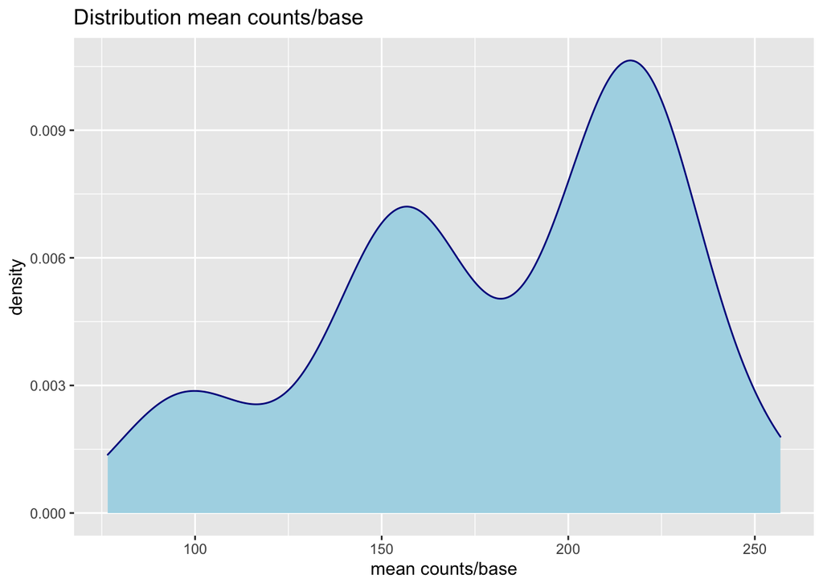

```r
Plot_distribution(mean_counts_base,"mean counts/base","Distribution mean counts/base")
```

## Identification of most different bases according to heteroplasmy between clusters

For detecting the difference in heteroplasmy values between two group of cells (i.e. two clusters), an unpaired two-samples Wilcoxon test is performed. In this case we run the test between the clusters *Winner Epiblast* and *Loser Epiblast*. As output, for each base, there is the adjusted p valued (FDR). Since we are performing the analysis on ERCC-Spikes-in as a technical control, we expect to see at most only few bases with a significant difference in heteroplasy between the two clusters.

```r
p_value_wilcox_test=get_wilcox_test(heteroplasmy_matrix_ci[,relevant_bases],cluster_ci,"Winner Epiblast","Loser Epiblast" ,index_ci)
```

We sort the bases according to the adjusted p value in order to identify the bases where the heteroplasmy is most different between the two clusters.

```r
p_value_wilcox_test_sort=sort(p_value_wilcox_test,decreasing = F)
```

The heteroplasmy and the corresponding allele frequencies for the most relevant bases (according to Wilcoxon test) are shown. Below the customized functions *plot_heteroplasmy_epiblast* and *plot_allele_frequency_epiblast* are used in order to keep the same colour assignment and notation used in https://www.nature.com/articles/s42255-021-00422-7. For general use please use functions *plot_heteroplasmy* and *plot_allele_frequency*

```
## [[1]]
## [[1]][[1]]
## list()
##
## [[1]][[2]]
```

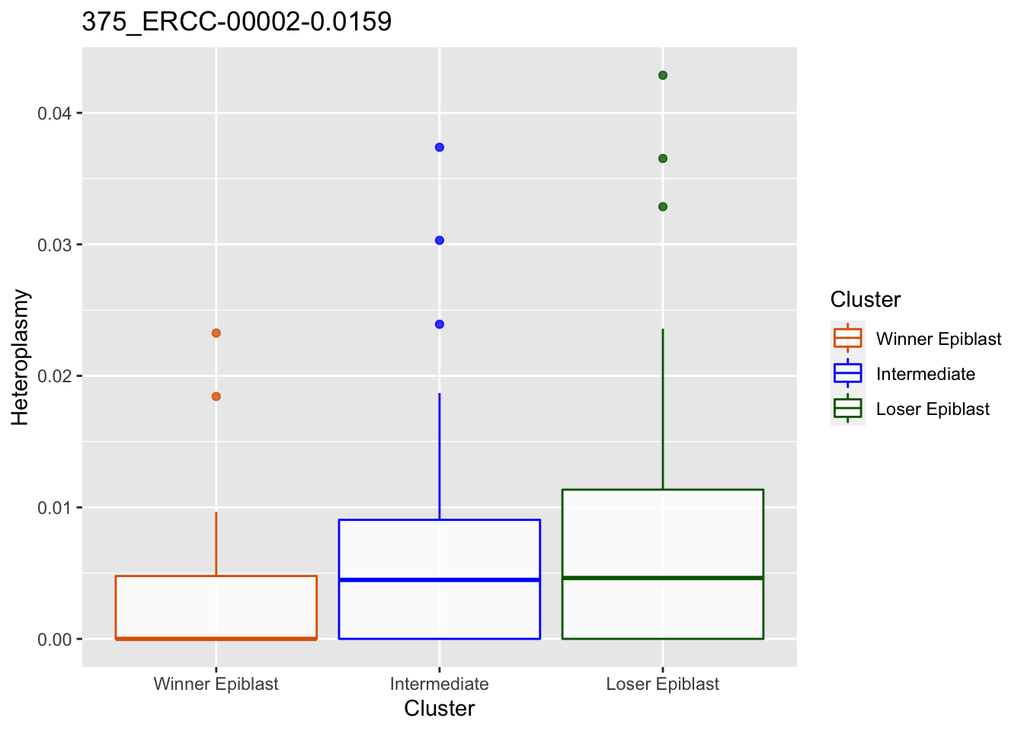

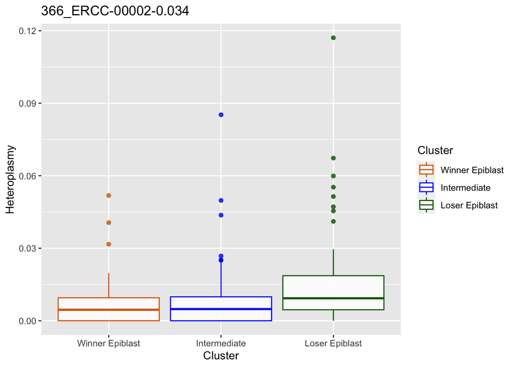

```r
q=list()
for ( i in 1:length(p_value_wilcox_test_sort[1:2])){
p=plot_heteroplasmy_epiblast(names(p_value_wilcox_test_sort)[i],heteroplasmy_matrix_ci,cluster_ci,index_ci)+ggtitle(paste(names(p_value_wilcox_test_sort)[i],round(p_value_wilcox_test_sort[i],4),sep="-"))
q=list(q,p)
}
q
```

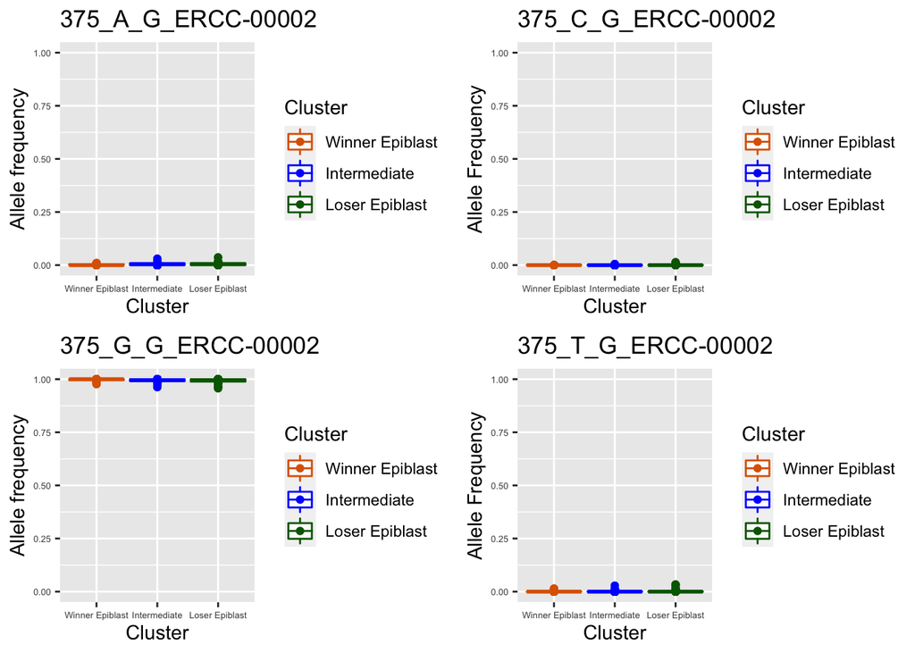

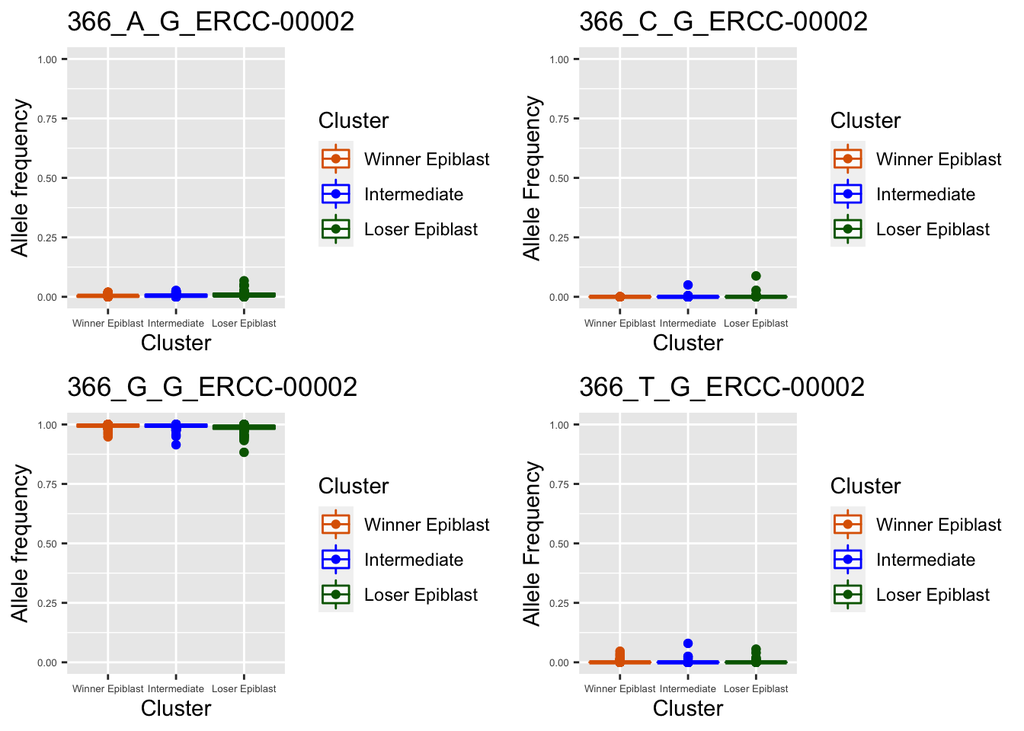

```r
q=list()
for ( i in names(p_value_wilcox_test_sort)[1:2]){
p=plot_allele_frequency_epiblast(i,heteroplasmy_matrix_ci,allele_matrix_ci,cluster_ci,name_position_qc,name_position_allele_qc,5,index_ci)
q=list(q,p)
}
```

```r
q
```

```
## [[1]]
## [[1]][[1]]
## list()
##
## [[1]][[2]]
## TableGrob (2 x 2) "arrange": 4 grobs
##   z     cells    name           grob
## 1 1 (1-1,1-1) arrange gtable[layout]
## 2 2 (1-1,2-2) arrange gtable[layout]
## 3 3 (2-2,1-1) arrange gtable[layout]
## 4 4 (2-2,2-2) arrange gtable[layout]
##
##
## [[2]]
## TableGrob (2 x 2) "arrange": 4 grobs
##   z     cells    name           grob
## 1 1 (1-1,1-1) arrange gtable[layout]
## 2 2 (1-1,2-2) arrange gtable[layout]
## 3 3 (2-2,1-1) arrange gtable[layout]
## 4 4 (2-2,2-2) arrange gtable[layout]
```

## Identication of most different bases according to heteroplasmy along pseudo-time

If for each cell the diffusion pseudo-time information is also available, then it is possible to detect the bases whose heteroplasmy changes in a significant way along pseudo-time. To perform this task three different methods are available: *GAM* (the adjusted p value provided by the GAM fit is assigned to each base), *pearson* and *spearman* (the adjusted p value provided by the pearson or spearman correlation test between heteroplasmy and losing score is assigned to each base). For more info see *?dpt_test* We notice that there are not positions with an FDR value below 0.001, as expected, since the heteroplasmy in the ERCC Spikes-In should not change in a significant way along the pseudo time.

```r
time=after_qc[row.names(heteroplasmy_matrix_ci),]$pseudo_time

dpt_analysis=dpt_test(heteroplasmy_matrix_ci[,relevant_bases],time,index_ci,method="GAM")

dpt_analysis_result_final=dpt_analysis[dpt_analysis$FDR_value<0.001,]
```

The heteroplasmy level for the top 2 relevant bases (according to GAM fit) is shown along pseudo time, with the black line denoting the GAM fit. The top 2 positions identified with the diffusion pseudo time analysis are equal to the top 2 positions detected with the Wilcoxon test based on clustering partition. Below the customized function *plot_dpt_epiblast* is used in order to keep the same colour assignment and notation used in https://www.nature.com/articles/s42255-021-00422-7. For general use, please use function *plot_dpt*.

```
## [[1]]
## [[1]][[1]]
## list()
##
## [[1]][[2]]
```

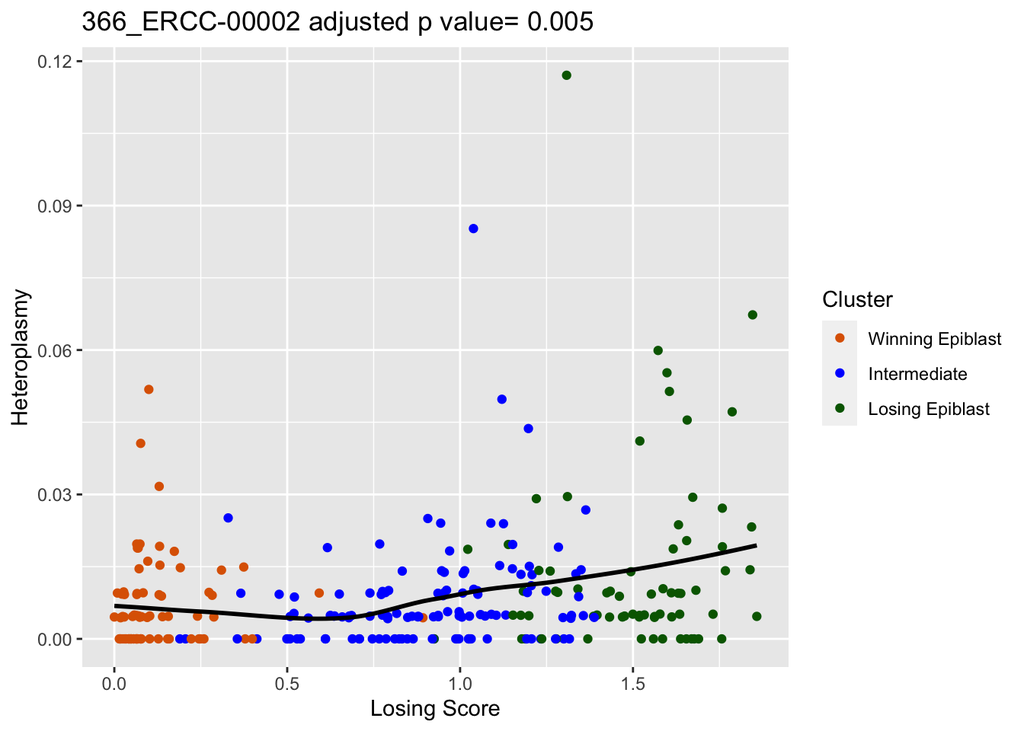

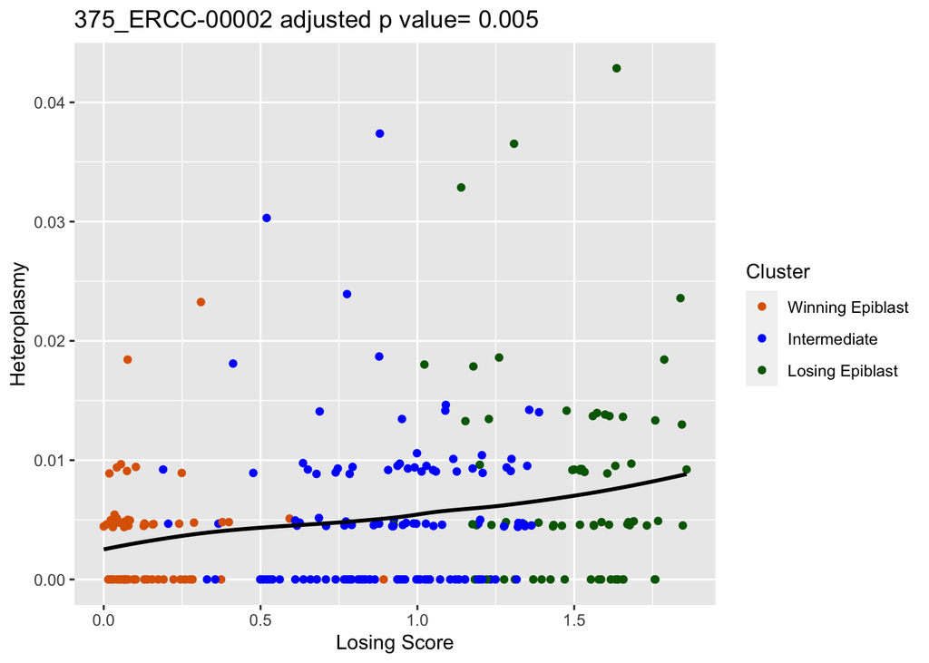

```r
q=list()
for ( i in dpt_analysis$Position[1:2]){
p=plot_dpt_epiblast(i,heteroplasmy_matrix_ci,cluster_ci,time,dpt_analysis,index_ci)
q=list(q,p)
}
q
```

Finally we can check if there is a batch effect in the most relevan positions (i.e. the heteroplasmy levels are constantly higher only in a specific batch). For the top 2 positions defined with the GAM fit there is a batch effect, since the heteroplasmy levels are higher mainly in the batch 5 and not in an homogeneus way across all the *Loser Epiblast* cluster. Below the customized function *plot_batch_epiblast* is used in order to keep the same colour assignment and notation used in https://www.nature.com/articles/s42255-021-00422-7. For general use, please use function *plot_batch*.

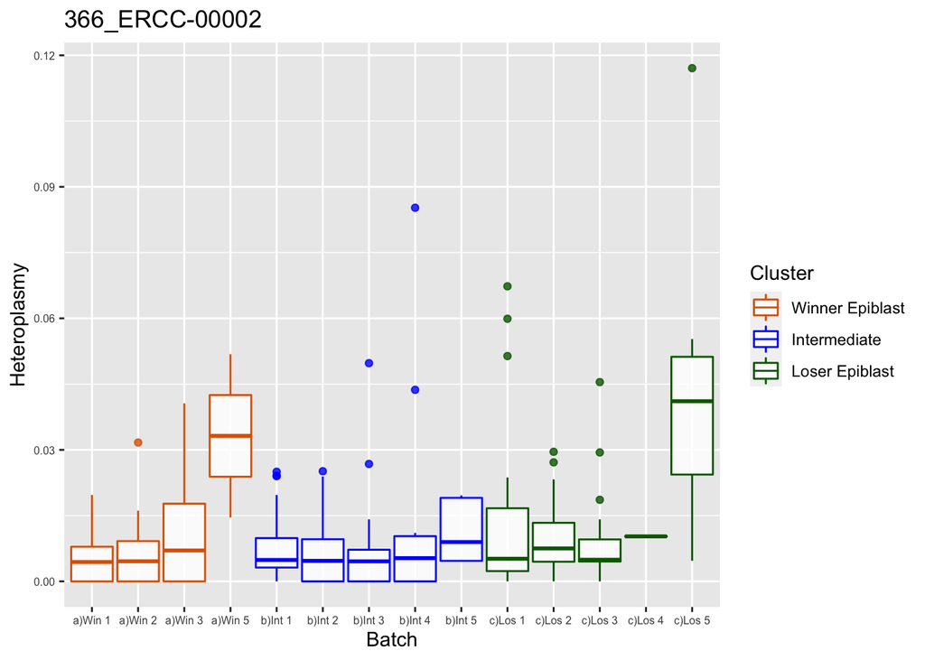

```r
after_qc_qc=after_qc[row.names(heteroplasmy_matrix_ci),]
batch=rep(0,length(after_qc_qc$cluster))
batch[after_qc_qc$cluster==1&after_qc_qc$batch=="1"]="a)Win 1"
batch[after_qc_qc$cluster==1&after_qc_qc$batch=="5"]="a)Win 5"
batch[after_qc_qc$cluster==1&after_qc_qc$batch=="4"]="a)Win 4"
batch[after_qc_qc$cluster==1&after_qc_qc$batch=="2"]="a)Win 2"
batch[after_qc_qc$cluster==1&after_qc_qc$batch=="3"]="a)Win 3"
batch[after_qc_qc$cluster==3&after_qc_qc$batch=="1"]="b)Int 1"
batch[after_qc_qc$cluster==3&after_qc_qc$batch=="5"]="b)Int 5"
batch[after_qc_qc$cluster==3&after_qc_qc$batch=="4"]="b)Int 4"
batch[after_qc_qc$cluster==3&after_qc_qc$batch=="2"]="b)Int 2"
batch[after_qc_qc$cluster==3&after_qc_qc$batch=="3"]="b)Int 3"
batch[after_qc_qc$cluster==4&after_qc_qc$batch=="1"]="c)Los 1"
batch[after_qc_qc$cluster==4&after_qc_qc$batch=="5"]="c)Los 5"
batch[after_qc_qc$cluster==4&after_qc_qc$batch=="4"]="c)Los 4"
batch[after_qc_qc$cluster==4&after_qc_qc$batch=="2"]="c)Los 2"
batch[after_qc_qc$cluster==4&after_qc_qc$batch=="3"]="c)Los 3"





colour=rep(0,length(batch))
colour[grep("Int",batch)]="#0000FF"
colour[grep("Los",batch)]="#006400"
colour[grep("Win",batch)]="#DD6400"



plot_batch_epiblast(dpt_analysis$Position[1],heteroplasmy_matrix_ci,batch,colour,cluster_ci,6,index_ci)
```

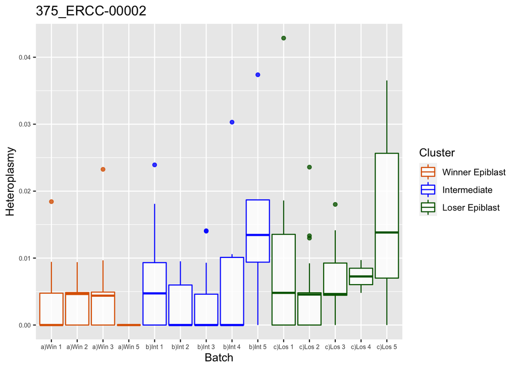

```r
plot_batch_epiblast(dpt_analysis$Position[2],heteroplasmy_matrix_ci,batch,colour,cluster_ci,6,index_ci)
```

## Batch effect analysis

We delete all the cells from batch 5 and then we repeat the full previous analysis.

```r
index_delete=which(!((batch=="a)Win 5")|(batch=="c)Los 5")|(batch=="b)Int 5")))
cells_fmk_epi_delete=cells_fmk_epi[index_delete]
my.clusters_delete=my.clusters[index_delete]
```

```r
epiblast_ci=get_heteroplasmy(matrix_allele_counts[cells_fmk_epi_delete,],name_position_allele,name_position,50,2000,filtering = 2,my.clusters_delete)
```

```r
sum_matrix=epiblast_ci[[1]]
sum_matrix_qc=epiblast_ci[[2]]
heteroplasmy_matrix_ci=epiblast_ci[[3]]
allele_matrix_ci=epiblast_ci[[4]]
cluster_ci=as.character(after_qc[row.names(heteroplasmy_matrix_ci),]$cluster)
cluster_ci[cluster_ci=="1"]="Winner Epiblast"
cluster_ci[cluster_ci=="3"]="Intermediate"
cluster_ci[cluster_ci=="4"]="Loser Epiblast"
condition_ci=as.character(after_qc[row.names(heteroplasmy_matrix_ci),]$condition)
index_ci=epiblast_ci[[5]]
```

```r
name_position_allele_qc=name_position_allele[name_position%in%colnames(sum_matrix_qc)]
name_position_qc=name_position[name_position%in%colnames(sum_matrix_qc)]
```

```r
relevant_bases=filter_bases(heteroplasmy_matrix_ci,0.01,10,index_ci)
```

```r
p_value_wilcox_test=get_wilcox_test(heteroplasmy_matrix_ci[,relevant_bases],cluster_ci,"Winner Epiblast","Loser Epiblast" ,index_ci)
```

```r
p_value_wilcox_test_sort=sort(p_value_wilcox_test,decreasing = F)
```

After deleting cells from batch 5, we notice that the FDR values assigned by unpaired two-samples Wilcoxon test are higher than in the previous section, showing the important role of batch 5 in making the difference between clusters stronger.

```
## [[1]]
## [[1]][[1]]
## list()
##
## [[1]][[2]]
```

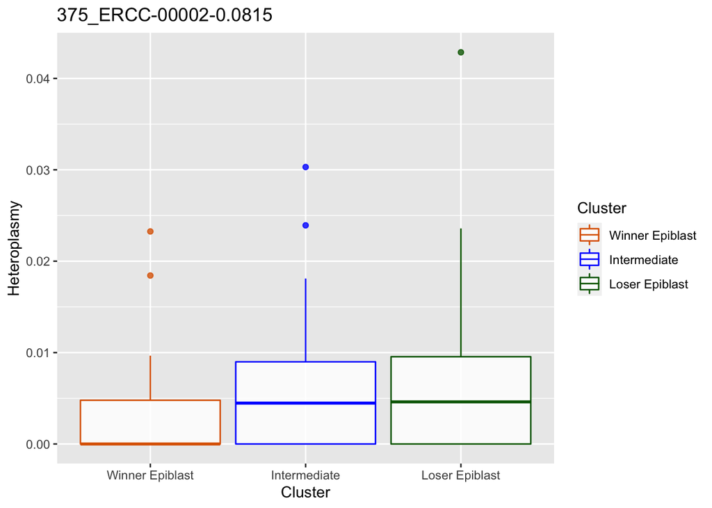

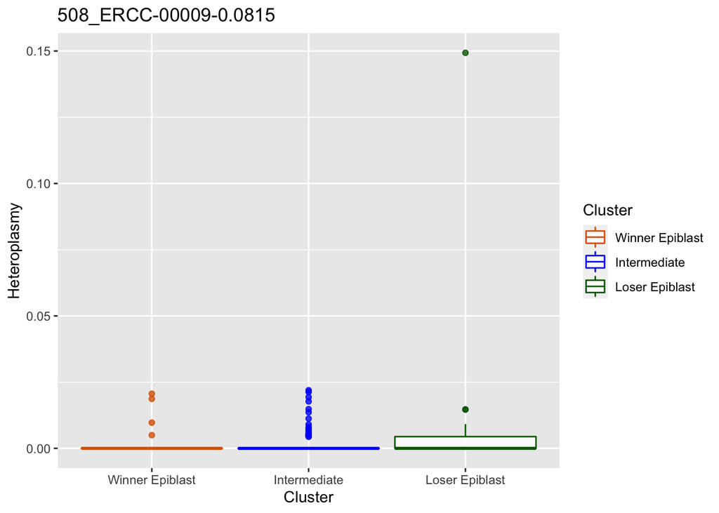

```r
q=list()
for ( i in 1:length(p_value_wilcox_test_sort[1:2])){
p=plot_heteroplasmy_epiblast(names(p_value_wilcox_test_sort)[i],heteroplasmy_matrix_ci,cluster_ci,index_ci)+ggtitle(paste(names(p_value_wilcox_test_sort)[i],round(p_value_wilcox_test_sort[i],4),sep="-"))
q=list(q,p)
}
q
```

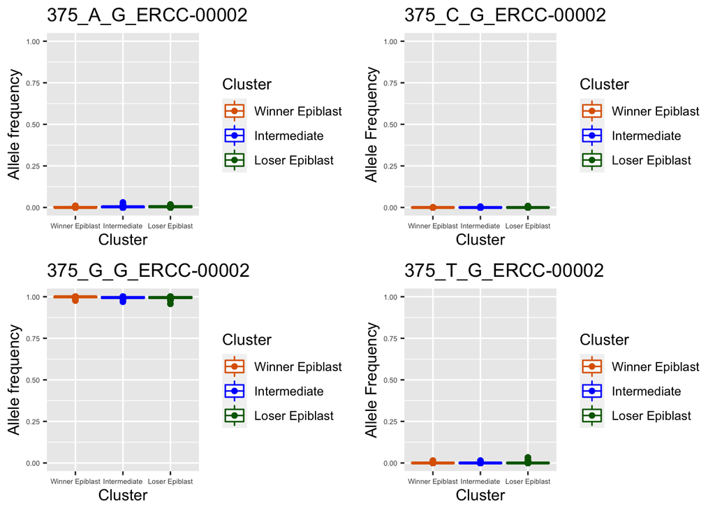

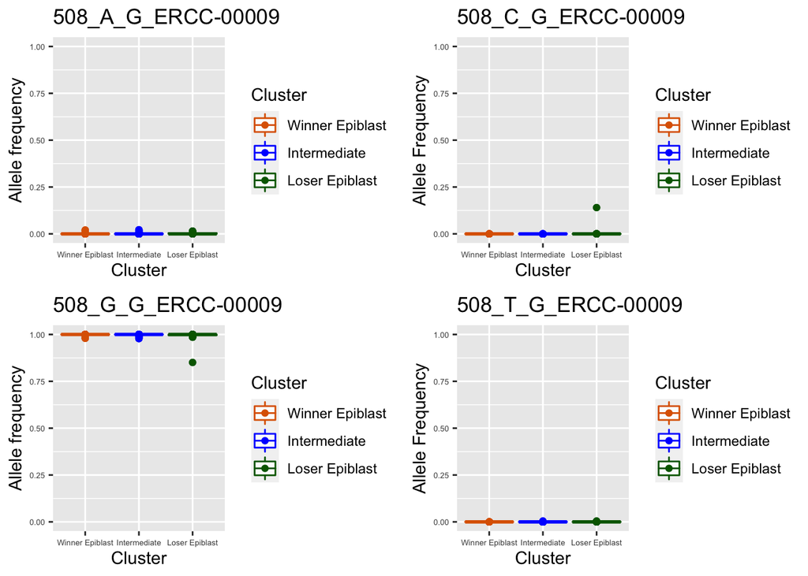

```r
q=list()
for ( i in names(p_value_wilcox_test_sort)[1:2]){
p=plot_allele_frequency_epiblast(i,heteroplasmy_matrix_ci,allele_matrix_ci,cluster_ci,name_position_qc,name_position_allele_qc,5,index_ci)
q=list(q,p)
}
```

```r
q
```

```
## [[1]]
## [[1]][[1]]
## list()
##
## [[1]][[2]]
## TableGrob (2 x 2) "arrange": 4 grobs
##   z     cells    name           grob
## 1 1 (1-1,1-1) arrange gtable[layout]
## 2 2 (1-1,2-2) arrange gtable[layout]
## 3 3 (2-2,1-1) arrange gtable[layout]
## 4 4 (2-2,2-2) arrange gtable[layout]
##
##
## [[2]]
## TableGrob (2 x 2) "arrange": 4 grobs
##   z     cells    name           grob
## 1 1 (1-1,1-1) arrange gtable[layout]
## 2 2 (1-1,2-2) arrange gtable[layout]
## 3 3 (2-2,1-1) arrange gtable[layout]
## 4 4 (2-2,2-2) arrange gtable[layout]
```

```r
library(utils)
```